# Reproducible Research

Nicholas A. C. Marino

nac.marino@gmail.com

github.com/nacmarino/introducaoR

# Elementos da Aula

1. Reproducible Research;
2. Controle de Versão;
3. Introdução ao GitHub;
4. `rmarkdown`.

## Reproducible Research

> **O que é *reproducible* research?**

Para alguns, é um termo que representa o fato de todo o achado a partir de um código e um dado poder ser reproduzido de forma identica caso este código e dado esteja disponível. Para outros, a definição é mais ampla, e envolve a noção de que que qualquer cientista usando os mesmos métodos pode chegar a resultados similares e fazer as mesmas inferências sobre um resultado já publicado - **é o coração da ciência**.

- Quais os elementos de um trabalho reprodutível (baseado em Ihle et al, 2017, Behav Ecol)?
1. **Reliability (Confiabilidade):** o pesquisador testou uma hipótese de forma objetiva (é o padrão de ouro);
   - *Falta de Confiabilidade*: falha em conduzir a pesquisa de acordo com o plano documentado.
2. **Reproducibility (Reprodutibilidade):** dada a mesma questão, dados brutos e métodos, alguém com mesmo conhecimento deve chegar na conclusão;
   - *Falta de Reprodutibilidade*: falha em garantir que reconduzir o mesmo projeto vai resultar no mesmo achado.
3. **Replicability (Replicabilidade):** validação de um experimento e/ou achado através de repetições em estudos independentes.
   - *Falta de Replicabilidade*: baixa probabilidade de que estudos independentes chegarem ao mesmo resultado.

Apesar de parecer fantástico, a ideia de que estamos em uma crise de reprodutibilidade não é algo tão distante assim…

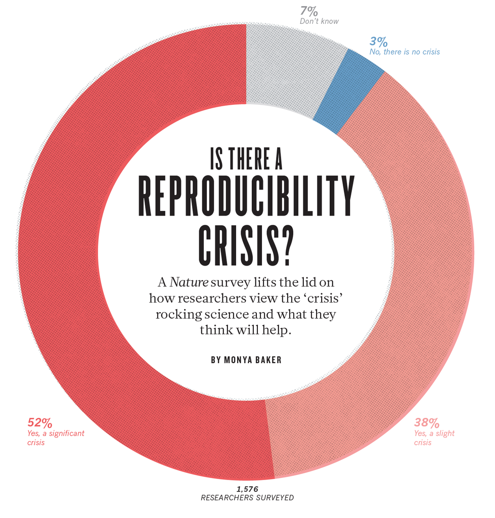

*Fonte: Baker & Penny, 2016, Nature, Is there a reproducibility crisis?*

Como identificar se o seu trabalho está sendo afetado pela crise de reprodutibilidade (baseado em Ihle et al, 2017, Behav Ecol)?

1. **Confiabilidade - você já…**
   1. tornou o nome das suas amostras não identificável de forma que você não saiba o que esperar delas?
   2. pediu para uma pessoa que não sabe nada sobre a sua hipótese coletar os dados (ou te ajudar)?
   3. continuou amostrando sabendo que existia um resultado nulo, de forma a aumentar o seu poder estatístico, e não reportou esta decisão a posteriori?
   4. reformulou uma hipótese baseado no que você encontrou, e apresentou o achado não esperado ‘fingindo’ que você já predizia ele desde o começo (*HARKing - Hypothesis After Results Are Known*)?
   5. reportou somente as medidas de interesse e deixou de fora outros que você testou?
   6. excluiu outliers baseado na significância dos seus resultados antes e depois da exclusão?
   7. excluiu, incluiu e transformou covariáveis para achar o melhor modelo, mas só reportou o modelo final?
2. **Reprodutibilidade - você já…**
   8. passou um tempão reprocessando e reanalisando os dados sem ser capaz de demonstrar para você ou outrém se todos os passos do processamento e análise foram identicos ao da vez anterior?
   9. achou um erro nos seus resultados sem saber de onde ele veio?
   10. perdeu parte dos dados ou notas sobre como processar os dados e obter outras variáveis de interesse?
   11. esqueceu qual análise você já havia feito?
   12. teve dificuldade de responder estas questões para um revisor, amigo e/ou colaborador?
3. **Replicabilidade - você já…**
   13. baseou todo um projeto em um achado sem poder saber se ele é válido na realidade?
   14. foi incapaz de replicar um estudo publicado anteriormente (inclusive, conceitualmente)?
   15. não conseguiu provar que um trabalho este sujeito ao viés de confirmação?

> **Pseudoscience (Richard P. Feynman):** ciência que não é ciência…segue os métodos, segue a forma, mas não chega a lugar algum, não gera leis e nem predições (e.g., a metáfora das pistas de avião; controvérsias alimentares; controvérsias sobre comportamento; controvérsias sobre o funcionamento das coisas).

E tem jeito?

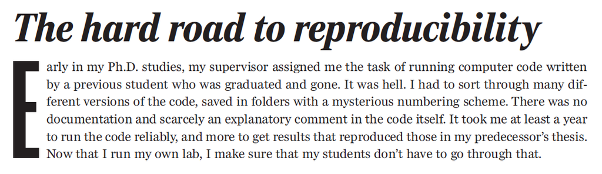

*Fonte: Barba, 2016, Science, The hard road to reproducibility?*

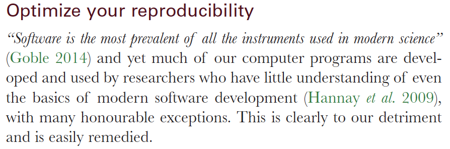

*Fonte: Ihle et al, 2017, Behav Ecol, Striving for transparent and credible research - practical guidelines for behavioral ecologists*

Reprodutibilidade é um hábito que pode ser adquirido e, uma vez que você começa a praticar, não tem mais como parar.